# Multi class classification using Logistic Regression, K nearest Neighbors and SVM SVM

## Flight Accident Severity Prediction.

##According to the FAA, 2,781,971 passengers fly every day in the US, as in June 2019. Passengers reckon that flying is very safe, considering strict inspections are conducted and security measures are taken to avoid and/or mitigate any mishappenings. However, there remain a few chances of unfortunate incidents.

## Loading Packages required

```r
library(ISLR)
library(tree)
library(ggplot2)
library(tidyverse)
library(MASS)
require(randomForest)
library(psych)
library(corrplot)
library(caret)
library(nnet)
```

##The dataset consists of certain parameters recorded during the incident` such as cabin temperature, turbulence experienced, number of safety complaints prior to the accident, number of days since the last inspection was conducted before the incident, an estimation of the pilot’s control given the various factors at play

### Loading our training dataset

```r
df<-read.csv("train.csv")
head(df)
```

|  | Severity | Safety_Score | Days_Since_Inspection | Total_Safety_Complaints | Control_Metric | Turbulence_In_gforces | Cabin_Temperature | Accident_Type_Code | Max_Elevation | Violations | Adverse_Weather_Metric | Accident_ID |
| --- | --- | --- | --- | --- | --- | --- | --- | --- | --- | --- | --- | --- |
| 1 | Minor_Damage_And_Injuries | 49.22374 | 14 | 22 | 71.28532 | 0.2721176 | 78.04 | 2 | 31335.48 | 3 | 0.424352083 | 7570 |
| 2 | Minor_Damage_And_Injuries | 62.46575 | 10 | 27 | 72.28806 | 0.4239387 | 84.54 | 2 | 26024.71 | 2 | 0.352349973 | 12128 |
| 3 | Significant_Damage_And_Fatalities | 63.05936 | 13 | 16 | 66.36281 | 0.3226044 | 78.86 | 7 | 39269.05 | 3 | 0.003363907 | 2181 |
| 4 | Significant_Damage_And_Serious_Injuries | 48.08219 | 11 | 9 | 74.70374 | 0.3370292 | 81.79 | 3 | 42771.50 | 1 | 0.211728167 | 5946 |
| 5 | Significant_Damage_And_Fatalities | 26.48402 | 13 | 25 | 47.94895 | 0.5411403 | 77.16 | 3 | 35509.23 | 2 | 0.176883368 | 9054 |
| 6 | Minor_Damage_And_Injuries | 43.33333 | 15 | 0 | 73.33637 | 0.4329542 | 78.63 | 2 | 29288.45 | 1 | 0.394504816 | 10947 |

### Loading our testing dataset. We’ll use this later.

```r
df2<-read.csv("test.csv")
head(df2)
```

|  | Safety_Score | Days_Since_Inspection | Total_Safety_Complaints | Control_Metric | Turbulence_In_gforces | Cabin_Temperature | Accident_Type_Code | Max_Elevation | Violations | Adverse_Weather_Metric | Accident_ID |
| --- | --- | --- | --- | --- | --- | --- | --- | --- | --- | --- | --- |
| 1 | 19.497717 | 16 | 6 | 72.15132 | 0.3889585 | 78.32 | 4 | 37949.72 | 2 | 0.069692447 | 1 |
| 2 | 58.173516 | 15 | 3 | 64.58523 | 0.2508410 | 78.60 | 7 | 30194.81 | 2 | 0.002777400 | 10 |
| 3 | 33.287671 | 15 | 3 | 64.72197 | 0.3366686 | 86.96 | 6 | 17572.93 | 1 | 0.004316395 | 14 |
| 4 | 3.287671 | 21 | 5 | 66.36281 | 0.4217750 | 80.86 | 3 | 40209.19 | 2 | 0.199990449 | 17 |
| 5 | 10.867580 | 18 | 2 | 56.10757 | 0.3132283 | 79.22 | 2 | 35495.53 | 2 | 0.483695846 | 21 |
| 6 | 44.794521 | 8 | 14 | 52.59799 | 0.3669607 | 77.08 | 2 | 15496.09 | 1 | 0.221040334 | 40 |

### Checking the size of our data

```r
dim(df)
```

```
## [1] 10000    12
```

### Looking for missing values

```r
colSums(is.na(df))
```

```
##                Severity            Safety_Score   Days_Since_Inspection
##                       0                       0                       0
## Total_Safety_Complaints          Control_Metric   Turbulence_In_gforces
##                       0                       0                       0
##       Cabin_Temperature      Accident_Type_Code           Max_Elevation
##                       0                       0                       0
##              Violations  Adverse_Weather_Metric             Accident_ID
##                       0                       0                       0
```

## Checking for duplicate values in our dataset

```r
df[!duplicated(df[1:12]),]
```

|  | Severity | Safety_Score | Days_Since_Inspection | Total_Safety_Complaints | Control_Metric | Turbulence_In_gforces | Cabin_Temperature | Accident_Type_Code | Max_Elevation | Violations | Adverse_Weather_Metric | Accident_ID |
| --- | --- | --- | --- | --- | --- | --- | --- | --- | --- | --- | --- | --- |
| 1 | Minor_Damage_And_Injuries | 49.223744 | 14 | 22 | 71.28532 | 0.2721176 | 78.04 | 2 | 31335.4768 | 3 | 0.4243520833 | 7570 |
| 2 | Minor_Damage_And_Injuries | 62.465753 | 10 | 27 | 72.28806 | 0.4239387 | 84.54 | 2 | 26024.7111 | 2 | 0.3523499726 | 12128 |
| 3 | Significant_Damage_And_Fatalities | 63.059361 | 13 | 16 | 66.36281 | 0.3226044 | 78.86 | 7 | 39269.0539 | 3 | 0.0033639070 | 2181 |
| 4 | Significant_Damage_And_Serious_Injuries | 48.082192 | 11 | 9 | 74.70374 | 0.3370292 | 81.79 | 3 | 42771.4992 | 1 | 0.2117281674 | 5946 |
| 5 | Significant_Damage_And_Fatalities | 26.484018 | 13 | 25 | 47.94895 | 0.5411403 | 77.16 | 3 | 35509.2285 | 2 | 0.1768833684 | 9054 |
| 6 | Minor_Damage_And_Injuries | 43.333333 | 15 | 0 | 73.33637 | 0.4329542 | 78.63 | 2 | 29288.4481 | 1 | 0.3945048164 | 10947 |
| 7 | Highly_Fatal_And_Damaging | 22.009132 | 15 | 10 | 62.85324 | 0.3146708 | 88.04 | 4 | 32342.1093 | 0 | 0.0588715559 | 4717 |
| 8 | Minor_Damage_And_Injuries | 24.703196 | 18 | 4 | 60.80219 | 0.5483527 | 83.48 | 4 | 22547.1952 | 2 | 0.0404193589 | 8008 |
| 9 | Highly_Fatal_And_Damaging | 54.840183 | 5 | 40 | 69.23428 | 0.3355867 | 78.24 | 2 | 45751.9834 | 0 | 0.6191857634 | 8179 |
| 10 | Significant_Damage_And_Serious_Injuries | 52.237443 | 6 | 4 | 57.42935 | 0.4654100 | 79.56 | 1 | 37933.3990 | 1 | 1.3892954966 | 6324 |

[output cut: 9990 more lines]

### Plotting the distributions of numeric columns

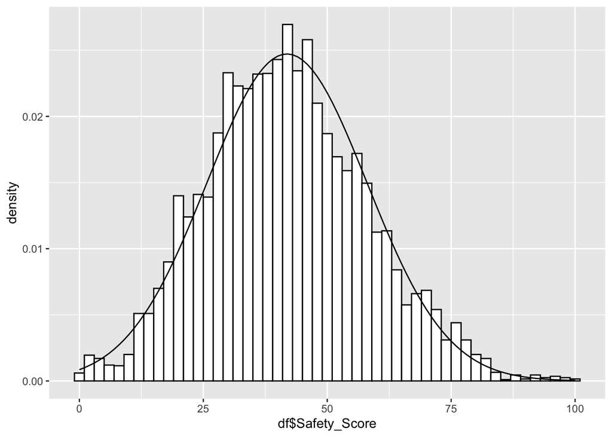

```r
ggplot(df,aes(x=df$Safety_Score))+geom_histogram(aes(y=..density..),color="black",fill="white",binwidth = 2)+stat_function(fun=dnorm,args = list(mean=mean(df$Safety_Score), sd=sd(df$Safety_Score)))
```

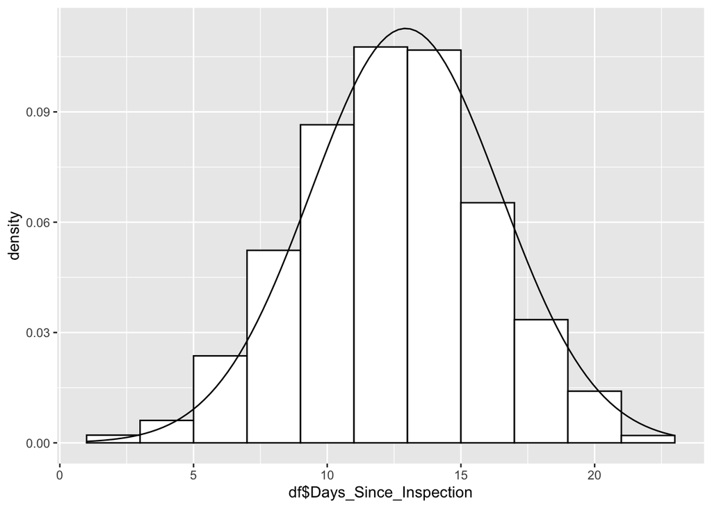

```r
ggplot(df,aes(x=df$Days_Since_Inspection))+geom_histogram(aes(y =..density..), color="black",fill="white",binwidth = 2)+stat_function(fun = dnorm, args = list(mean = mean(df$Days_Since_Inspection), sd = sd(df$Days_Since_Inspection)))
```

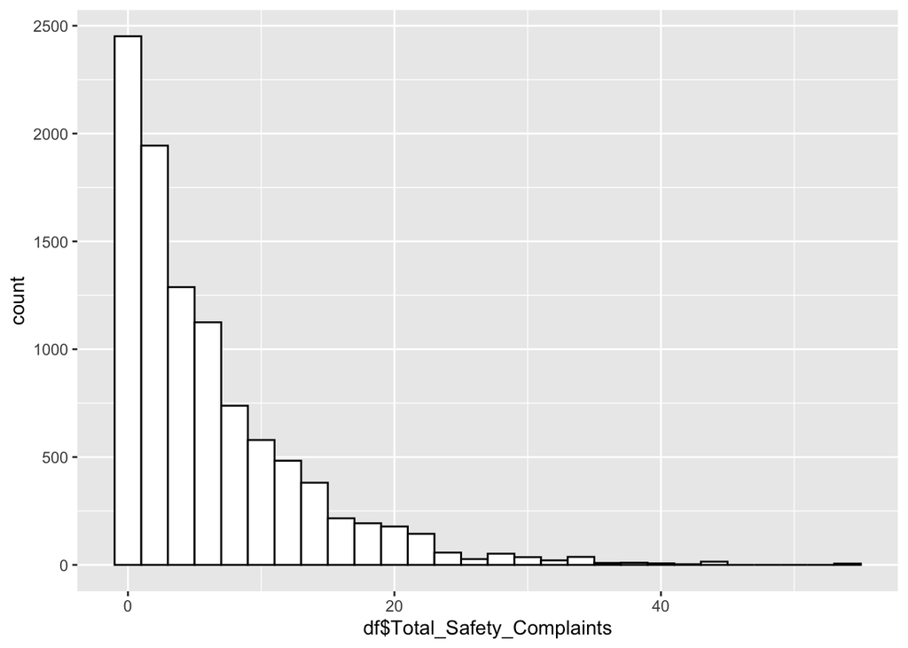

```r
ggplot(df,aes(x=df$Total_Safety_Complaints))+geom_histogram(color="black",fill="white",binwidth = 2)
```

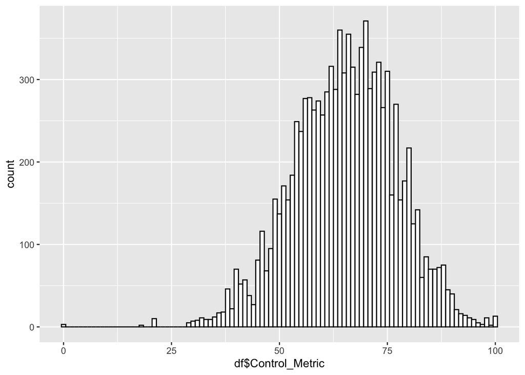

```r
ggplot(df,aes(x=df$Control_Metric))+geom_histogram(color="black", fill="white",binwidth=1)
```

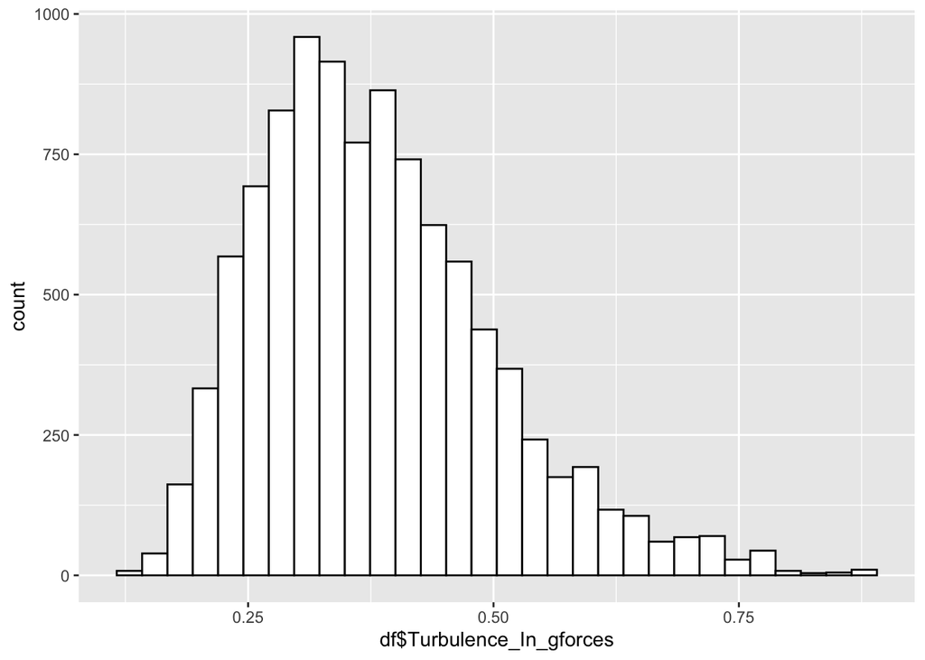

```r
ggplot(df,aes(x=df$Turbulence_In_gforces))+geom_histogram(color="black", fill="white")
```

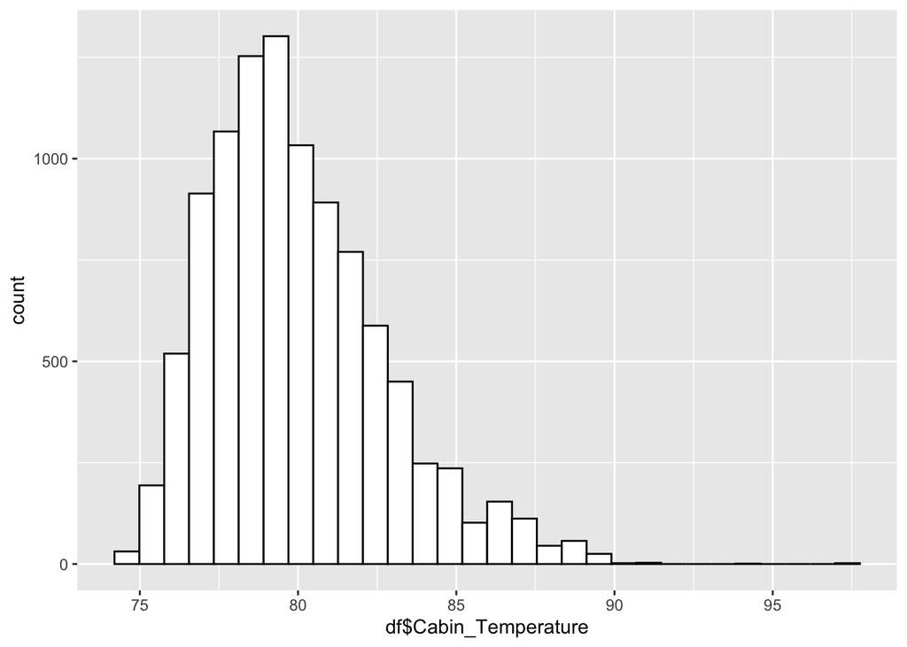

```r
ggplot(df,aes(x=df$Cabin_Temperature))+geom_histogram(color="black", fill="white")
```

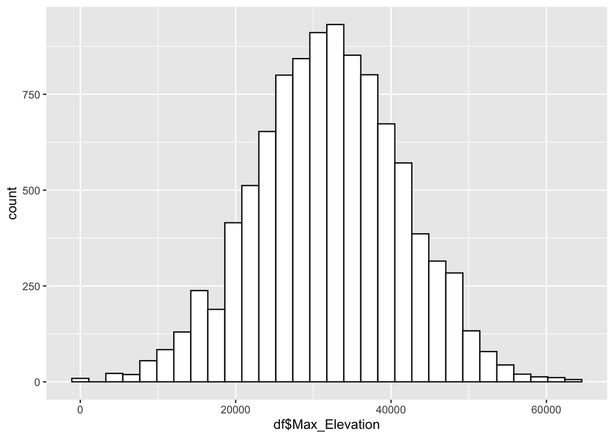

```r
ggplot(df,aes(x=df$Max_Elevation))+geom_histogram(color="black", fill="white")
```

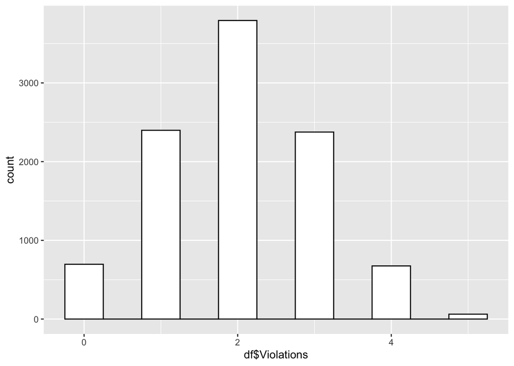

```r
ggplot(df,aes(x=df$Violations))+geom_histogram(color="black", fill="white",binwidth=0.5)
```

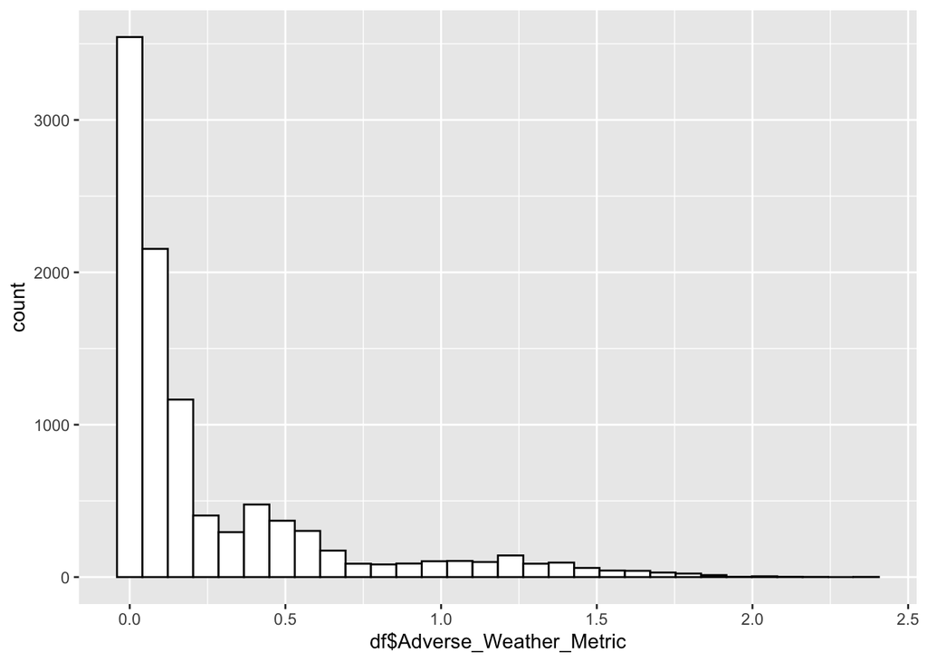

```r
ggplot(df,aes(x=df$Adverse_Weather_Metric))+geom_histogram(color="black", fill="white")
```

### PLotting and Mapping the correlation of the predictors

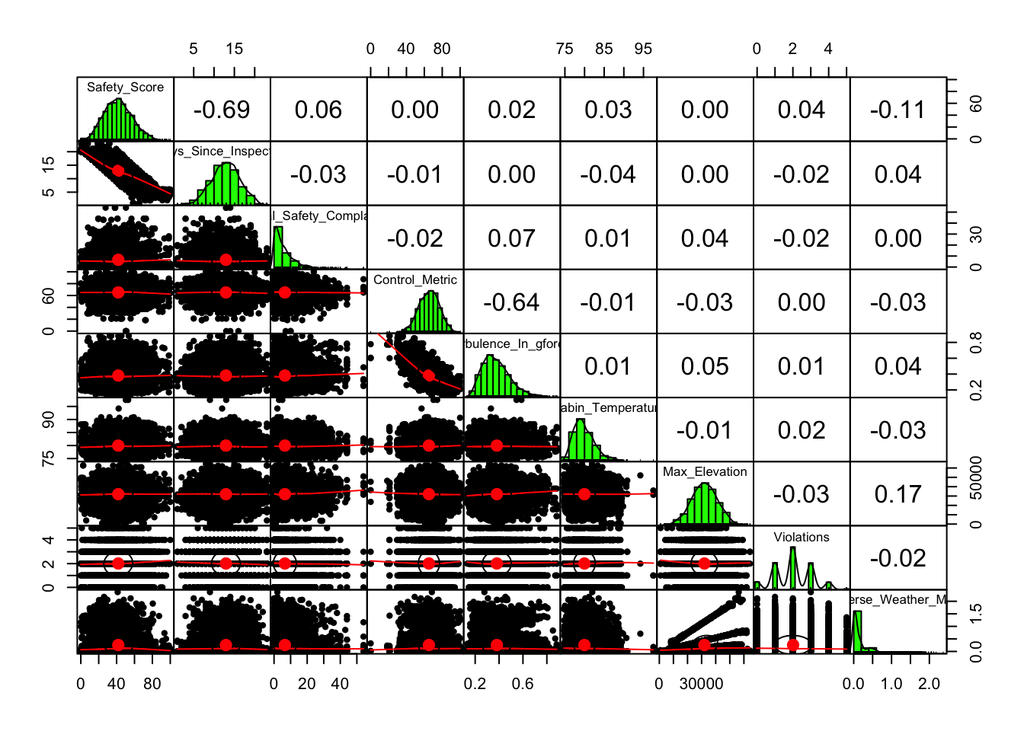

```r
pairs.panels(df[c("Safety_Score","Days_Since_Inspection","Total_Safety_Complaints","Control_Metric",
"Turbulence_In_gforces","Cabin_Temperature","Max_Elevation","Violations","Adverse_Weather_Metric")],hist.col="green",gap=0)
```

###Mapping the correlation

```r
mydf<-df[,c("Safety_Score","Days_Since_Inspection","Total_Safety_Complaints","Control_Metric",
"Turbulence_In_gforces","Cabin_Temperature","Max_Elevation","Violations","Adverse_Weather_Metric")]
res<-cor(mydf)
round(res,2)
```

```
##                         Safety_Score Days_Since_Inspection
## Safety_Score                    1.00                 -0.69
## Days_Since_Inspection          -0.69                  1.00
## Total_Safety_Complaints         0.06                 -0.03
## Control_Metric                  0.00                 -0.01
## Turbulence_In_gforces           0.02                  0.00
## Cabin_Temperature               0.03                 -0.04
## Max_Elevation                   0.00                  0.00
## Violations                      0.04                 -0.02
## Adverse_Weather_Metric         -0.11                  0.04
##                         Total_Safety_Complaints Control_Metric
## Safety_Score                               0.06           0.00
## Days_Since_Inspection                     -0.03          -0.01
## Total_Safety_Complaints                    1.00          -0.02
## Control_Metric                            -0.02           1.00
## Turbulence_In_gforces                      0.07          -0.64
## Cabin_Temperature                          0.01          -0.01
## Max_Elevation                              0.04          -0.03
## Violations                                -0.02           0.00
## Adverse_Weather_Metric                     0.00          -0.03
##                         Turbulence_In_gforces Cabin_Temperature Max_Elevation
## Safety_Score                             0.02              0.03          0.00
## Days_Since_Inspection                    0.00             -0.04          0.00
## Total_Safety_Complaints                  0.07              0.01          0.04
## Control_Metric                          -0.64             -0.01         -0.03
## Turbulence_In_gforces                    1.00              0.01          0.05
## Cabin_Temperature                        0.01              1.00         -0.01
## Max_Elevation                            0.05             -0.01          1.00
## Violations                               0.01              0.02         -0.03
## Adverse_Weather_Metric                   0.04             -0.03          0.17
##                         Violations Adverse_Weather_Metric
## Safety_Score                  0.04                  -0.11
## Days_Since_Inspection        -0.02                   0.04
## Total_Safety_Complaints      -0.02                   0.00
## Control_Metric                0.00                  -0.03
## Turbulence_In_gforces         0.01                   0.04
## Cabin_Temperature             0.02                  -0.03
## Max_Elevation                -0.03                   0.17
## Violations                    1.00                  -0.02
## Adverse_Weather_Metric       -0.02                   1.00
```

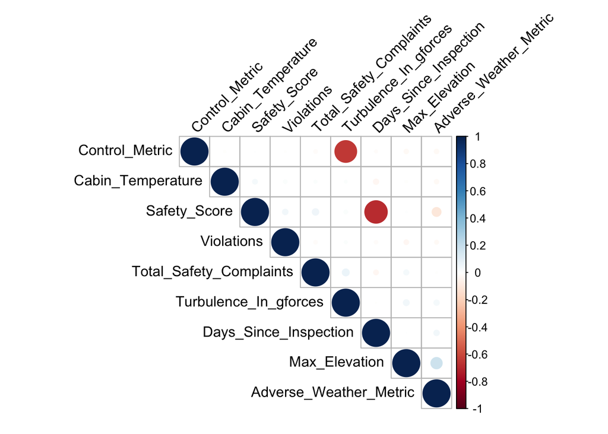

```r
corrplot(res, type = "upper", order = "hclust",
         tl.col = "black", tl.srt = 45)
```

```r
df$Severity <- as.factor(df$Severity)
#df$Control_Metric <- as.factor(df$Control_Metric)
#df$Max_Elevation <- as.factor(df$Max_Elevation)
#df$Safety_Score <- as.factor(df$Safety_Score)
#df$Turbulence_In_gforces <- as.factor(df$Turbulence_In_gforces)
#df$Violations <- as.factor(df$Violations)
#df$Days_Since_Inspection <- as.factor(df$Days_Since_Inspection)
#df$Cabin_Temperature <- as.factor(df$Cabin_Temperature)
#df$Adverse_Weather_Metric <- as.factor(df$Adverse_Weather_Metric)
#df$Total_Safety_Complaints <- as.factor(df$Total_Safety_Complaints)
#df$Accident_Type_Code <- as.factor(df$Accident_Type_Code)
#df$Accident_ID <- as.factor(df$Accident_ID)
```

### Splitting our dataset into train and test sets. I am keeping the size of training data 80% of the whole data.

```r
df<-df[,-12]
sample_size=floor(0.8*nrow(df))
set.seed(123)
df_train= sample(seq_len(nrow(df)),size = sample_size)
train=df[df_train,]
test=df[-df_train,]
```

### MultiClassification Logistic Regression

```r
model1<-nnet::multinom(Severity~.,data = train)
summary(model1)
```

```
## Call:
## nnet::multinom(formula = Severity ~ ., data = train)
##
## Coefficients:
##                                         (Intercept) Safety_Score
## Minor_Damage_And_Injuries                -11.668941    0.1826360
## Significant_Damage_And_Fatalities         -9.137193    0.1521960
## Significant_Damage_And_Serious_Injuries   -8.873214    0.1122385
##                                         Days_Since_Inspection
## Minor_Damage_And_Injuries                           0.6217623
## Significant_Damage_And_Fatalities                   0.5115922
## Significant_Damage_And_Serious_Injuries             0.3664565
##                                         Total_Safety_Complaints Control_Metric
## Minor_Damage_And_Injuries                          3.415895e-03    -0.02342091
## Significant_Damage_And_Fatalities                 -8.583185e-03    -0.05866111
## Significant_Damage_And_Serious_Injuries            6.495886e-06     0.01198562
##                                         Turbulence_In_gforces Cabin_Temperature
## Minor_Damage_And_Injuries                           0.1146925       -0.02205745
## Significant_Damage_And_Fatalities                  -0.1372987       -0.02367616
## Significant_Damage_And_Serious_Injuries             1.4926753       -0.02647164
##                                         Accident_Type_Code Max_Elevation
## Minor_Damage_And_Injuries                       -0.2460281  8.696850e-06
## Significant_Damage_And_Fatalities                0.4128667 -2.470323e-05
## Significant_Damage_And_Serious_Injuries          0.1166352  7.893311e-06
##                                         Violations Adverse_Weather_Metric
## Minor_Damage_And_Injuries               0.03319810             -0.4674305
## Significant_Damage_And_Fatalities       0.20136329              1.7071741
## Significant_Damage_And_Serious_Injuries 0.03647066             -0.6688087
##
## Std. Errors:
##                                          (Intercept) Safety_Score
## Minor_Damage_And_Injuries               2.108019e-05  0.002414889
## Significant_Damage_And_Fatalities       2.177762e-05  0.002544796
## Significant_Damage_And_Serious_Injuries 2.118830e-05  0.002170567
##                                         Days_Since_Inspection
## Minor_Damage_And_Injuries                        0.0007418008
## Significant_Damage_And_Fatalities                0.0007380472
## Significant_Damage_And_Serious_Injuries          0.0006968389
##                                         Total_Safety_Complaints Control_Metric
## Minor_Damage_And_Injuries                           0.002896688    0.001942259
## Significant_Damage_And_Fatalities                   0.002913341    0.002045456
## Significant_Damage_And_Serious_Injuries             0.002939284    0.001933970
##                                         Turbulence_In_gforces Cabin_Temperature
## Minor_Damage_And_Injuries                        2.542427e-05       0.001828848
## Significant_Damage_And_Fatalities                2.761131e-05       0.001879044
## Significant_Damage_And_Serious_Injuries          2.674169e-05       0.001855816
##                                         Accident_Type_Code Max_Elevation
## Minor_Damage_And_Injuries                     6.101029e-05  3.795995e-06
## Significant_Damage_And_Fatalities             8.109606e-05  4.091934e-06
## Significant_Damage_And_Serious_Injuries       7.821873e-05  3.408058e-06
##                                           Violations Adverse_Weather_Metric
## Minor_Damage_And_Injuries               3.941765e-05           7.408916e-06
## Significant_Damage_And_Fatalities       4.459623e-05           1.287239e-05
## Significant_Damage_And_Serious_Injuries 4.392495e-05           3.397635e-06
##
## Residual Deviance: 17462.35
## AIC: 17528.35
```

### Predicitng on our test data

```r
predicted.classes <- model1 %>% predict(test)
```

```r
head(predicted.classes)
```

```
## [1] Minor_Damage_And_Injuries
## [2] Minor_Damage_And_Injuries
## [3] Highly_Fatal_And_Damaging
## [4] Significant_Damage_And_Fatalities
## [5] Significant_Damage_And_Serious_Injuries
## [6] Significant_Damage_And_Serious_Injuries
## 4 Levels: Highly_Fatal_And_Damaging ... Significant_Damage_And_Serious_Injuries
```

### checking the accuracy our the model

```r
mean(predicted.classes == test$Severity)
```

```
## [1] 0.6205
```

```r
head(test[,1])
```

```
## [1] Minor_Damage_And_Injuries
## [2] Significant_Damage_And_Fatalities
## [3] Highly_Fatal_And_Damaging
## [4] Highly_Fatal_And_Damaging
## [5] Significant_Damage_And_Serious_Injuries
## [6] Significant_Damage_And_Serious_Injuries
## 4 Levels: Highly_Fatal_And_Damaging ... Significant_Damage_And_Serious_Injuries
```

```r
table(test[,1],knn_df,dnn=c("True","Predicted"))
```

```
##                                          Predicted
## True                                      Highly_Fatal_And_Damaging
##   Highly_Fatal_And_Damaging                                     351
##   Minor_Damage_And_Injuries                                      71
##   Significant_Damage_And_Fatalities                              61
##   Significant_Damage_And_Serious_Injuries                       106
##                                          Predicted
## True                                      Minor_Damage_And_Injuries
##   Highly_Fatal_And_Damaging                                      78
##   Minor_Damage_And_Injuries                                     251
##   Significant_Damage_And_Fatalities                             104
##   Significant_Damage_And_Serious_Injuries                       125
##                                          Predicted
## True                                      Significant_Damage_And_Fatalities
##   Highly_Fatal_And_Damaging                                              47
##   Minor_Damage_And_Injuries                                              64
##   Significant_Damage_And_Fatalities                                     153
##   Significant_Damage_And_Serious_Injuries                                36
##                                          Predicted
## True                                      Significant_Damage_And_Serious_Injuries
##   Highly_Fatal_And_Damaging                                                   109
##   Minor_Damage_And_Injuries                                                   117
##   Significant_Damage_And_Fatalities                                            44
##   Significant_Damage_And_Serious_Injuries                                     283
```

### Checking the accuracy of our model

```r
mean(knn_df==test[,1])
```

```
## [1] 0.519
```

```r
miserror <- sum(test[,1]!=knn_df)/nrow(test)
miserror
```

```
## [1] 0.481
```

### Plotting The decision tree

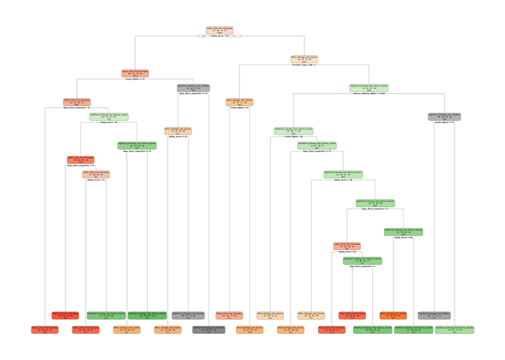

```r
#install.packages("rpart.plot")
library(rpart.plot)
rpart.plot(model3)
```

### Testing the model

```r
test$pred <- predict(model3,test[,-1],type="class")
```

```r
table(test$pred, test$Severity)
```

```
##
##                                           Highly_Fatal_And_Damaging
##   Highly_Fatal_And_Damaging                                     431
##   Minor_Damage_And_Injuries                                     109
##   Significant_Damage_And_Fatalities                              25
##   Significant_Damage_And_Serious_Injuries                        20
##
##                                           Minor_Damage_And_Injuries
##   Highly_Fatal_And_Damaging                                      24
##   Minor_Damage_And_Injuries                                     441
##   Significant_Damage_And_Fatalities                              25
##   Significant_Damage_And_Serious_Injuries                        13
##
##                                           Significant_Damage_And_Fatalities
##   Highly_Fatal_And_Damaging                                              20
##   Minor_Damage_And_Injuries                                             123
##   Significant_Damage_And_Fatalities                                     212
##   Significant_Damage_And_Serious_Injuries                                 7
##
##                                           Significant_Damage_And_Serious_Injuries
##   Highly_Fatal_And_Damaging                                                    21
##   Minor_Damage_And_Injuries                                                   110
##   Significant_Damage_And_Fatalities                                            19
##   Significant_Damage_And_Serious_Injuries                                     400
```

### Checking the accuracy

```r
mean(test$pred == test$Severity)
```

```
## [1] 0.742
```

### Random Forest Model

```r
library(randomForest)
model4<-randomForest(Severity~.,data = train, xtree=400,mtry=6,nodesize=2)
```

```r
test$pred_rf2 <- predict(model4,test[,-1])
```

```r
table(test$pred_rf2, test[,1])
```

```
##
##                                           Highly_Fatal_And_Damaging
##   Highly_Fatal_And_Damaging                                     546
##   Minor_Damage_And_Injuries                                       9
##   Significant_Damage_And_Fatalities                              16
##   Significant_Damage_And_Serious_Injuries                        14
##
##                                           Minor_Damage_And_Injuries
##   Highly_Fatal_And_Damaging                                      10
##   Minor_Damage_And_Injuries                                     485
##   Significant_Damage_And_Fatalities                               3
##   Significant_Damage_And_Serious_Injuries                         5
##
##                                           Significant_Damage_And_Fatalities
##   Highly_Fatal_And_Damaging                                               5
##   Minor_Damage_And_Injuries                                               7
##   Significant_Damage_And_Fatalities                                     345
##   Significant_Damage_And_Serious_Injuries                                 5
##
##                                           Significant_Damage_And_Serious_Injuries
##   Highly_Fatal_And_Damaging                                                    10
##   Minor_Damage_And_Injuries                                                    21
##   Significant_Damage_And_Fatalities                                             3
##   Significant_Damage_And_Serious_Injuries                                     516
```

### Checking the accuracy of Random Forest

```r
mean(test$pred_rf2==test[,1])
```

```
## [1] 0.946
```

```r
print(model4)
```

```
##
## Call:
##  randomForest(formula = Severity ~ ., data = train, xtree = 400,      mtry = 6, nodesize = 2)
##                Type of random forest: classification
##                      Number of trees: 500
## No. of variables tried at each split: 6
##
##         OOB estimate of  error rate: 4.9%
## Confusion matrix:
##                                         Highly_Fatal_And_Damaging
## Highly_Fatal_And_Damaging                                    2324
## Minor_Damage_And_Injuries                                      52
## Significant_Damage_And_Fatalities                              12
## Significant_Damage_And_Serious_Injuries                        39
##                                         Minor_Damage_And_Injuries
## Highly_Fatal_And_Damaging                                      53
## Minor_Damage_And_Injuries                                    1932
## Significant_Damage_And_Fatalities                              21
## Significant_Damage_And_Serious_Injuries                        56
##                                         Significant_Damage_And_Fatalities
## Highly_Fatal_And_Damaging                                              54
## Minor_Damage_And_Injuries                                              22
## Significant_Damage_And_Fatalities                                    1275
## Significant_Damage_And_Serious_Injuries                                 7
##                                         Significant_Damage_And_Serious_Injuries
## Highly_Fatal_And_Damaging                                                    33
## Minor_Damage_And_Injuries                                                    18
## Significant_Damage_And_Fatalities                                            25
## Significant_Damage_And_Serious_Injuries                                    2077
##                                         class.error
## Highly_Fatal_And_Damaging                0.05681818
## Minor_Damage_And_Injuries                0.04545455
## Significant_Damage_And_Fatalities        0.04351088
## Significant_Damage_And_Serious_Injuries  0.04681046
```

### Tuning the Random Forest Model using Bagging

```r
#install.packages("bagRboostR")
library(bagRboostR)
```

```r
df2$Severity <- predict(model4,df2)
```

```r
oob = trainControl(method = "oob")
cv_5 = trainControl(method = "cv", number = 5)
```

### Checking for the best parameters

```r
rf_grid =  expand.grid(mtry = 1:10)

set.seed(825)
flight_rf_tune = train(Severity ~ ., data = train,
                     method = "rf",
                     trControl = oob,
                     verbose = FALSE,
                     tuneGrid = rf_grid)
flight_rf_tune
```

```
## Random Forest
##
## 8000 samples
##   10 predictor
##    4 classes: 'Highly_Fatal_And_Damaging', 'Minor_Damage_And_Injuries', 'Significant_Damage_And_Fatalities', 'Significant_Damage_And_Serious_Injuries'
##
## No pre-processing
## Resampling results across tuning parameters:
##
##   mtry  Accuracy  Kappa
##    1    0.817125  0.7522339
##    2    0.900750  0.8657478
##    3    0.931250  0.9070590
##    4    0.942250  0.9219407
##    5    0.948125  0.9298797
##    6    0.951750  0.9347763
##    7    0.951250  0.9341052
##    8    0.952750  0.9361257
##    9    0.952250  0.9354564
##   10    0.951750  0.9347667
##
## Accuracy was used to select the optimal model using the largest value.
## The final value used for the model was mtry = 8.
```

```r
calc_acc = function(actual, predicted) {
  mean(actual == predicted)
}
```

```r
flight_rf_tune$bestTune
```

|  | mtry |
| --- | --- |
| 8 | 8 |

### Predicting our Random Forest model on test tata

```r
df2$Severity <- predict(flight_rf_tune,df2)
```

### Training a Support Vector Model

```r
set.seed(120)
model5 <- train(Severity~.,data=train,method="svmLinear", trControl = trainControl("cv", number = 10),
  preProcess = c("center","scale"))
```

```r
test$pred_svm <- model5 %>% predict(test[,-1])
head(test$pred_svm)
```

```
## [1] Minor_Damage_And_Injuries
## [2] Minor_Damage_And_Injuries
## [3] Highly_Fatal_And_Damaging
## [4] Significant_Damage_And_Fatalities
## [5] Significant_Damage_And_Serious_Injuries
## [6] Significant_Damage_And_Serious_Injuries
## 4 Levels: Highly_Fatal_And_Damaging ... Significant_Damage_And_Serious_Injuries
```

### Checking the accuracy

```r
mean(test$pred_svm == test[,1])
```

```
## [1] 0.7045
```

### Conclusion:

#### Building this Machine Learning models can help us to anticipate and classify the severity of any airplane accident based on past incidents. With this, all airlines, even the entire aviation industry, can predict the severity of airplane accidents caused due to various factors and, correspondingly, have a plan of action to minimize the risk associated with them.

#### Further in the analysis I am planning to impove the accuracy and prediction capability by boosting the model using gradient boost.

```r
#gbm_grid =  expand.grid(interaction.depth = 1:5, n.trees = (1:6) * 500, shrinkage = c(0.001, 0.01, 0.1),n.minobsinnode = 10)
```

```r
#install.packages("gbm")
#library(gbm)
#flight_gbm_tune = train(Severity ~ ., data = train,method = "gbm", trControl = cv_5, verbose = FALSE, tuneGrid = gbm_grid)
```